# Video Games

Catherine Williams

August 5, 2019

##### *[Tidy Tuesday](https://twitter.com/catrwilliams/status/1158509332712976384)*

# 1 Project Description

Tidy Tuesday has a weekly data project aimed at the R ecosystem. An emphasis is placed on understanding how to summarize and arrange data to make meaningful charts with ggplot2, tidyr, dplyr, and other tools in the tidyverse ecosystem.

# 2 Dataset

Data came from [Steam Spy](https://cruiseofdimensionality.home.blog/2019/07/24/pc-video-games-we-still-play/). The data includes time played, ownership, release date, publishing information, and for some a metascore.

# 3 Setup

## 3.1 Load Libraries

```r
if (!require("pacman")) install.packages("pacman")
pacman::p_load("tidyverse","naniar","zoo","textclean","lubridate","grid","gridExtra")

theme_set(theme_minimal())
```

## 3.2 Import Data

```r
df <- read_csv("https://raw.githubusercontent.com/rfordatascience/tidytuesday/master/data/2019/2019-07-30/video_games.csv")
```

# 4 Data Wrangling & Analysis

- There are 26688 observations and 10 variables.

## 4.1 View Data

```r
glimpse(df)
```

```
## Observations: 26,688
## Variables: 10
## $ number           <dbl> 1, 3, 21, 47, 36, 52, 2, 4, 14, 40, 9, 17, 43...
## $ game             <chr> "Half-Life 2", "Counter-Strike: Source", "Cou...
## $ release_date     <chr> "Nov 16, 2004", "Nov 1, 2004", "Mar 1, 2004",...
## $ price            <dbl> 9.99, 9.99, 9.99, 4.99, 9.99, NA, 14.99, 4.99...
## $ owners           <chr> "10,000,000Â ..Â 20,000,000", "10,000,000Â ..Â 20...
## $ developer        <chr> "Valve", "Valve", "Valve", "Valve", "Valve", ...
## $ publisher        <chr> "Valve", "Valve", "Valve", "Valve", "Valve", ...
## $ average_playtime <dbl> 110, 236, 10, 0, 0, 16, 0, 0, 0, 0, 0, 0, 0, ...
## $ median_playtime  <dbl> 66, 128, 3, 0, 0, 10, 0, 0, 0, 0, 0, 0, 0, 27...
## $ metascore        <dbl> 96, 88, 65, NA, NA, NA, 93, 87, 73, NA, 80, 6...
```

```r
head(df)
```

```
## # A tibble: 6 x 10
##   number game  release_date price owners developer publisher
##    <dbl> <chr> <chr>        <dbl> <chr>  <chr>     <chr>
## 1      1 Half~ Nov 16, 2004  9.99 10,00~ Valve     Valve
## 2      3 Coun~ Nov 1, 2004   9.99 10,00~ Valve     Valve
## 3     21 Coun~ Mar 1, 2004   9.99 10,00~ Valve     Valve
## 4     47 Half~ Nov 1, 2004   4.99 5,000~ Valve     Valve
## 5     36 Half~ Jun 1, 2004   9.99 2,000~ Valve     Valve
## 6     52 CS2D  Dec 24, 2004 NA    1,000~ Unreal S~ Unreal S~
## # ... with 3 more variables: average_playtime <dbl>,
## #   median_playtime <dbl>, metascore <dbl>
```

```r
summary(df)
```

```
##      number         game           release_date           price
##  Min.   :   1   Length:26688       Length:26688       Min.   :  0.490
##  1st Qu.: 821   Class :character   Class :character   1st Qu.:  2.990
##  Median :2356   Mode  :character   Mode  :character   Median :  5.990
##  Mean   :2904                                         Mean   :  8.947
##  3rd Qu.:4523                                         3rd Qu.:  9.990
##  Max.   :8846                                         Max.   :595.990
##                                                       NA's   :3095
##     owners           developer          publisher
##  Length:26688       Length:26688       Length:26688
##  Class :character   Class :character   Class :character
##  Mode  :character   Mode  :character   Mode  :character
##
##
##
##
##  average_playtime   median_playtime     metascore
##  Min.   :   0.000   Min.   :   0.00   Min.   :20.00
##  1st Qu.:   0.000   1st Qu.:   0.00   1st Qu.:66.00
##  Median :   0.000   Median :   0.00   Median :73.00
##  Mean   :   9.057   Mean   :   5.16   Mean   :71.89
##  3rd Qu.:   0.000   3rd Qu.:   0.00   3rd Qu.:80.00
##  Max.   :5670.000   Max.   :3293.00   Max.   :98.00
##  NA's   :9          NA's   :12        NA's   :23838
```

```r
sapply(df, function(x) n_distinct(x)) %>% sort()
```

```
##           owners        metascore            price  median_playtime
##               13               74              200              297
## average_playtime     release_date           number        publisher
##              387             2977             8846            13954
##        developer             game
##            16753            26611
```

## 4.2 Missing Values

View missing values in more detail.

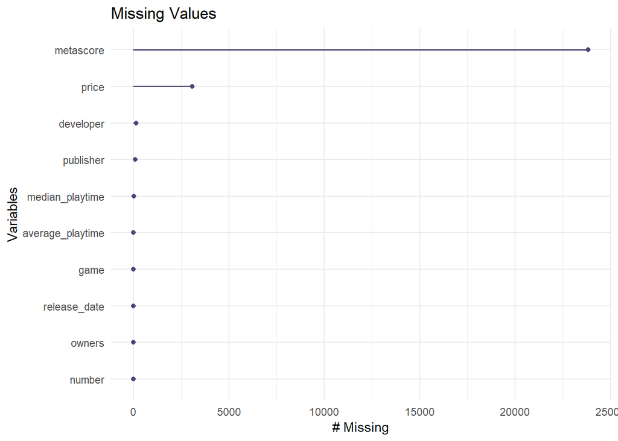

```r
#Visualize missing values
gg_miss_var(df) + labs(title="Missing Values")
```

```r
#see count of missing values
na_values <- function(df){
  na <- colSums(is.na(df)) %>% sort(decreasing=TRUE)
  na[na>0]
}

na_values(df)
```

```
##        metascore            price        developer        publisher
##            23838             3095              151               95
##  median_playtime average_playtime             game
##               12                9                3
```

## 4.3 Data Wrangling

Remove/replace missing values and drop unnecessary columns

```r
#group by most specific attributes to less specific to get the mean for missing price
groups <- c("game","publisher","developer")

for(group in groups){
  df <- df %>% group_by(get(group)) %>% mutate(price = na.aggregate(price)) %>% ungroup()
}

df$average_playtime[(is.na(df$average_playtime))] <- 0

#check missing values again
na_values(df)
```

```
##       metascore           price       developer      get(group)
##           23838            1979             151             151
##       publisher median_playtime            game
##              95              12               3
```

```r
#for the remaining missing prices, use the mean of the entire dataset
df <- df %>% mutate(price = na.aggregate(price)) %>% select(-11,-metascore)

na_values(df)
```

```
##       developer       publisher median_playtime            game
##             151              95              12               3
```

```r
#check for string abnormalities in game
check_text(df$game)
```

```
##
##
## ===========
## CONTRACTION
## ===========
##
## The following observations contain contractions:
##
## 523, 988, 1450, 2029, 3304, 3546, 3836, 3859, 3992, 5328...[truncated]...
##
## This issue affected the following text:
##
## 523: Sam & Max 205: What's New Beelzebub?
## ...[truncated]...
## 988: nail'd
## ...[truncated]...
## 1450: Who's That Flying?!
## ...[truncated]...
## 2029: Monaco: What's Yours Is Mine
## ...[truncated]...
## 3304: Let's Sing
## ...[truncated]...
## 3546: It's A Wipe!
## ...[truncated]...
## 3836: Frayed Knights: The Skull of S'makh-Daon
## ...[truncated]...
## 3859: It's time to get out from the solar system
## ...[truncated]...
## 3992: Who's Your Daddy
## ...[truncated]...
## 5328: I Can't Escape: Darkness
## ...[truncated]...
##
## *Suggestion: Consider running `replace_contraction`
##
##
## =====
## DIGIT
## =====
##
```

[output cut: 416 more lines]

```
##
##
## ===
## URL
## ===
##
## The following observations contain URLs:
##
## 26024
##
## This issue affected the following text:
##
## 26024: Driftpunk Racer
##
## *Suggestion: Consider using `replace_url`
```

```r
#fix strings and other data anomalies
df <- df %>% mutate(game = str_replace_all(game, "[^\x20-\x7E]", ""), #removes unicode characters
                    game = replace_non_ascii(game), #did not work for everything. line above is better
                    game = replace_emoticon(game),
                    game = replace_date(game),
                    game = replace_hash(game),
                    game = replace_kern(game),
                    game = str_trim(game),
                    game = str_squish(game),
                    game = str_to_title(game),
                    game = str_replace_all(game, "\\d/\\d", ""),
                    game = str_replace(game, "^[:punct:]+", ""),
                    game = str_replace(game, "\\|.*", ""),
                    game = str_replace(game, "(?<=\\w):(?=\\w)", ": "),
                    game = str_replace(game, "\\s-|-\\s", ": "),
                    game = paste0(game, ": "), #add : to end to make it easy to extract into a group
                    game = str_replace(game, "[:punct:]:$", ":"),
                    game_group = str_extract(game,"([^:]+(?=[:punct:]+\\s))"),
                    game_group = str_trunc(game_group,25),
                    game = str_replace(game, ": $", ""), #clean it up: remove the trailing :
                    publisher = str_replace_all(publisher, "[:punct:]+", ""),
                    publisher = str_replace_all(publisher, "[^\x20-\x7E]", ""),
                    publisher = str_to_title(publisher),
                    owners = str_replace_all(owners, ",", ""),
                    owners_lower = str_extract_all(owners, "\\d+(?=\\s\\.\\.\\s)") %>% as.integer(),
                    owners_upper = str_extract_all(owners, "(?<=\\s\\.\\.\\s)\\d+") %>% as.integer(),
                    release_date = as.Date(release_date, "%b %d, %Y"),
                    average_playtime_group = case_when(average_playtime <= max(average_playtime)*0.2 ~ "Very Low",
                                                       average_playtime > max(average_playtime)*0.2 &
                                                         average_playtime <= max(average_playtime)*0.4 ~ "Low",
                                                       average_playtime > max(average_playtime)*0.4 &
                                                         average_playtime <= max(average_playtime)*0.6 ~ "Medium",
                                                       average_playtime > max(average_playtime)*0.6 &
                                                         average_playtime <= max(average_playtime)*0.8 ~ "High",
                                                       average_playtime > max(average_playtime)*0.8 ~ "Very High"),
                    average_playtime_group = fct_relevel(average_playtime_group,c("Very Low","Low","Medium","High","Very High")))

#remove rows that do not have any alpha characters
df <- keep_row(df, "game","\\w+")

#change strings back to factors to make them easier to work with
df <- df %>% mutate_if(is.character, as.factor)
```

# 5 Visualizations

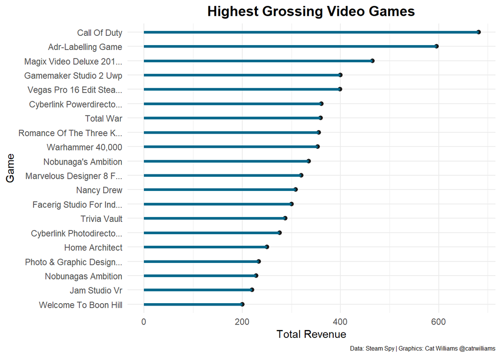

```r
df_price <- df %>% group_by(game_group) %>% summarize(total_revenue=sum(price)) %>% ungroup() %>%
  mutate(game_group = fct_reorder(game_group, total_revenue)) %>% arrange(total_revenue) %>% tail(20)

#practice with lollipop chart
df_price %>% ggplot(aes(game_group,total_revenue))+
  geom_point(size=1.75, color="gray10")+
  geom_segment(aes(x=game_group, xend=game_group, y=0, yend=total_revenue), size=1.25, color="deepskyblue4")+
  scale_color_gradient()+
  coord_flip()+
  labs(title="Highest Grossing Video Games", caption="Data: Steam Spy | Graphics: Cat Williams @catrwilliams",
       x = "Game", y = "Total Revenue")+
  theme(plot.title = element_text(size=14, hjust=0.5, face="bold"),
        plot.caption = element_text(size=6))
```

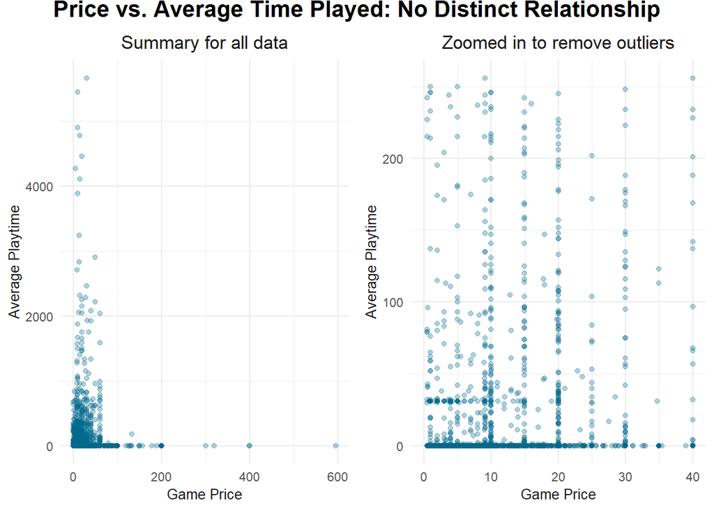

```r
#################

#determine if there is a relationship between price and average playtime
outliers <- boxplot(df$price, plot=FALSE)$out
price_lim <- summary(outliers)[["3rd Qu."]]

outliers <- boxplot(df$average_playtime, plot=FALSE)$out
playtime_lim <- summary(outliers)[["3rd Qu."]]

p1 <- df %>% ggplot(aes(price, average_playtime))+
  geom_point(alpha=0.3,color="deepskyblue4")+
  labs(title="Summary for all data",x="Game Price",y="Average Playtime")+
  theme(text= element_text(color="gray10"),
        plot.title = element_text(size=13,hjust=0.5),
        axis.title = element_text(size=10))

p2 <- df %>% ggplot(aes(price, average_playtime))+
  geom_point(alpha=0.3,color="deepskyblue4")+
  xlim(0,price_lim)+
  ylim(0,playtime_lim)+
  labs(title="Zoomed in to remove outliers",x="Game Price",y="Average Playtime")+
  theme(text= element_text(color="gray10"),
        plot.title = element_text(size=13,hjust=0.5),
        axis.title = element_text(size=10))

tg <- grobTree(textGrob("Price vs. Average Time Played: No Distinct Relationship",
                        y=1,
                        vjust=1,
                        gp=gpar(fontface="bold", fontsize = 16, color="deepskyblue4")),
               cl="titlegrob")

heightDetails.titlegrob <- function(x) do.call(sum,lapply(x$children, grobHeight))

#create final plot
p3 <- grid.arrange(arrangeGrob(p1,p2,nrow=1),top = tg)
```

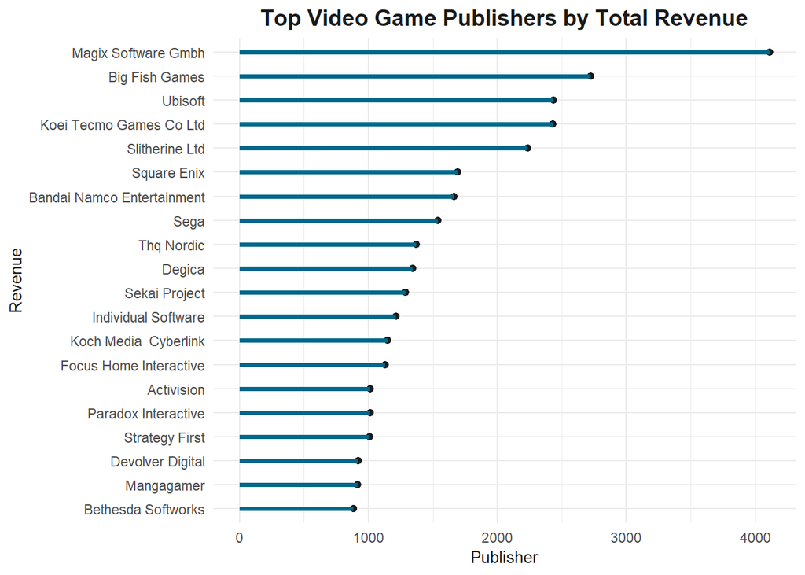

```r
#################

df_publisher <- df %>% group_by(publisher) %>% summarize(total_price=sum(price)) %>% ungroup() %>%
  filter(publisher != "") %>% mutate(publisher = fct_reorder(publisher, total_price)) %>%
  arrange(total_price) %>% tail(20)

df_publisher %>% ggplot(aes(publisher, total_price))+
  #geom_col(fill="deepskyblue4")+
  geom_point(size=1.75, color="gray10")+
  geom_segment(aes(x=publisher, xend=publisher, y=0, yend=total_price), size=1.25, color="deepskyblue4")+
  coord_flip()+
  labs(title="Top Video Game Publishers by Total Revenue", x="Revenue", y="Publisher")+
  theme(text= element_text(color="gray10"),
        plot.title = element_text(size=14, hjust=0.5, face="bold"),
        axis.title = element_text(size=10))
```

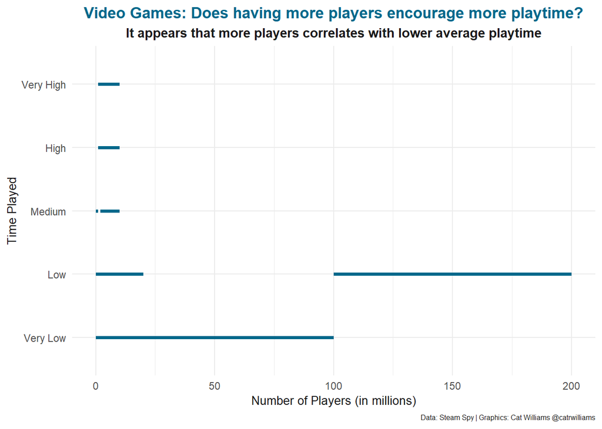

```r
#################

#does having more players encourage more playtime?
df %>% ggplot()+
  geom_segment(aes(x=owners_lower, xend=owners_upper, y=average_playtime_group, yend=average_playtime_group),
               size=1.25, color="deepskyblue4")+
  scale_x_continuous(labels=c("0","50","100","150","200"))+
  labs(title="Video Games: Does having more players encourage more playtime?",
       subtitle="It appears that more players correlates with lower average playtime",
       x="Number of Players (in millions)", y="Time Played",
       caption="Data: Steam Spy | Graphics: Cat Williams @catrwilliams")+
  theme(plot.title=element_text(hjust=0.5, color="deepskyblue4", face="bold"),
        text = element_text(color="gray10"),
        plot.subtitle=element_text(hjust=0.5, face="bold"),
        plot.caption = element_text(size=6),
        axis.title = element_text(size=10))
```

```r
ggsave("video-games.png")
```

# 6 Conclusions

I do not have specific knowledge of most video games, however, I have heard the names of many of the highest grossing video games in passing. They also appear to be of multiple genres (ie. war, mystery, trivia) which comes as a surprise to me. I would not have placed a trivia game in the top 20 highest grossing video games.

Another surprise to me is that there is no obvious relationship between average time played and the price of the game. I would have expected more expensive games to be played more as it is a larger investment and logically higher prices tend to equate to better things. What these charts do show is that lower priced games are slightly more popular, due to the concentration of the data points closer to 0.

As for top video game publishers, it appears that Magix Software is doing much better than the other publishers. Big Fish Games, Ubisoft, Koei Tecmo Games, and Slitherine are in a slightly higher bracket than the other top performers. After that, revenue numbers seem to decrease gradually. I also wonder if the top publishers correlate to the highest grossing games. Further analysis would need to be done to determine this.

Lastly, having more overall players for a particular game does not encourage more playtime. At first thought it would seem that more popular games would have more playtime. Based on the data, however, one may infer that because there are more people involved (perhaps only occasional players) with more popular games, it skews the average rankings.